# Exploratory Factor Analysis

Mariana O. S. Silva

Last Updated: maio 15, 2020

# tl;dr

[Exploratory Factor Analysis](https://en.wikipedia.org/wiki/Exploratory_factor_analysis) (EFA) is a statistical approach for determining the correlation among the variables in a dataset. EFA can statistically explain the variance among the observed variable and condense a set of the observed variable into the unobserved variable called factors (a grouping of variables based on strong correlations). Observed variables are modeled as a linear combination of factors and error terms. Each factor explains a particular amount of variance in the observed variables and can help in data interpretations by reducing the number of variables.

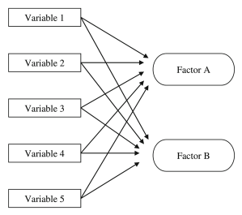

This dataset contains 9 regions with 27 music genre networks, in total, containing 6 different topological edge measures. The edge measures were the following:

- **preferential_attatchment** = probability of connecting in the future (the more neighbors in common, the more likely they are to connect in the future)
- **common_neighbors** = number of common neighbors on the network
- **neighborhood_overlap** = fraction of the number of common neighbors (edges with low neighborhood_overlap consist of nodes traveling in “social circles”, having almost nobody in common = local bridges)
- **edge_betweenness** = number of the shortest paths that go through an edge in a graph or network (edges with a high edge betweenness centrality score represent a bridge-like connector between two parts of a network and the removal of which may affect the communication between many pairs of nodes through the shortest paths between them)
- **resource_allocation** = fraction of a resource (for example, information or something else) that a node can send to another node through its common neighbors
- **weight** = number of collaborations between two music genres (which is statistically correlated with the possibility that these two genres will collaborate in the future)

## Global

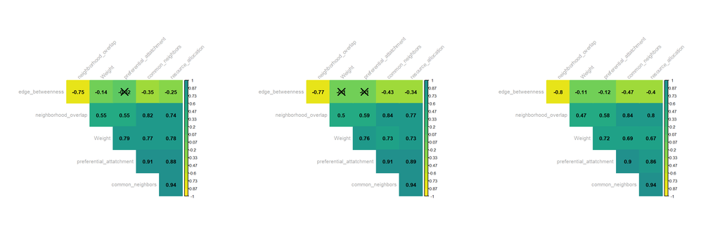

### Choosing the Number of Factors

Before conducting the EFA, we determine the number of factors via the `Parallel Analysis` to find an acceptable number of factors. *Parallel* Analysis is an alternative technique that compares the scree plot (line plot of the eigenvalues of factors) of the observed data with that of a random data matrix of the same size as the original.

The console would show the maximum number of factors we can consider.

```
## Parallel analysis suggests that the number of factors =  2  and the number of components =  NA
```

```
## Parallel analysis suggests that the number of factors =  3  and the number of components =  NA
```

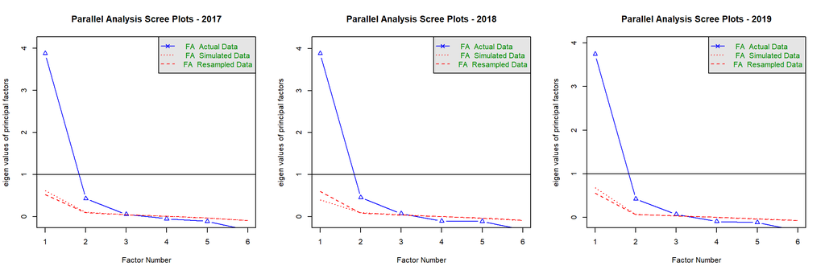

```
## Parallel analysis suggests that the number of factors =  3  and the number of components =  NA
```

In the scree plot generated, the blue line shows eigenvalues of actual data and the two red lines (placed on top of each other) show simulated and resampled data. Here we look at the large drops in the actual data and spot the point where it levels off to the right. Also, we locate the point of inflection – the point where the gap between simulated data and actual data tends to be minimum.

### Factor Analysis

Now that we have the probable number of factors, we can carry out exploratory factor analysis. Here, we will use the `fa()` function of the `psych` package. The following are the arguments we will provide:

- r – Raw data or correlation or covariance matrix
- nfactors – Number of factors to extract
- rotate – Type of rotation (`Varimax` and `Oblimin` are the most popular)
- fm – Factoring method (e.g., `Minimum Residual (OLS)`, `Maximum Liklihood`, `Principal Axis`, etc)

In our case, we will select oblique rotation (`rotate = "oblimin"`) as we believe that there is a correlation in the factors. Note that `Varimax` rotation is used under the assumption that the factors are completely uncorrelated. We will use `Ordinary Least Squared/ols` factoring (`fm = "ols"`), as it is known to provide results similar to `Maximum Likelihood` without assuming a multivariate normal distribution and derives solutions through iterative eigendecomposition like a principal axis.

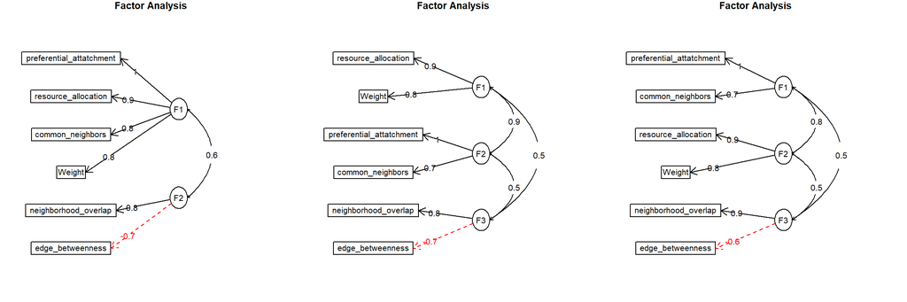

### Adequacy Test

First, we should check the root mean square of residuals (RMSR). An acceptable value should be closer to 0. Finally, we must check the Tucker-Lewis Index (TLI). An acceptable value must be greater over 0.9.

```
## Factor Analysis using method =  ols
## Call: fa(r = data_2017, nfactors = 2, rotate = "oblimin", fm = "ols")
## Standardized loadings (pattern matrix) based upon correlation matrix
##                             1     2   h2    u2 com
## Weight                   0.76 -0.04 0.55 0.450 1.0
## common_neighbors         0.82  0.25 0.98 0.019 1.2
## neighborhood_overlap     0.20  0.84 0.94 0.063 1.1
## resource_allocation      0.92  0.08 0.93 0.071 1.0
## preferential_attatchment 1.01 -0.12 0.90 0.102 1.0
## edge_betweenness         0.20 -0.70 0.37 0.632 1.2
##
##                       [,1] [,2]
## SS loadings           3.30 1.37
## Proportion Var        0.55 0.23
## Cumulative Var        0.55 0.78
## Proportion Explained  0.71 0.29
## Cumulative Proportion 0.71 1.00
##
##  With factor correlations of
##      [,1] [,2]
## [1,] 1.00 0.57
## [2,] 0.57 1.00
##
## Mean item complexity =  1.1
## Test of the hypothesis that 2 factors are sufficient.
##
## The degrees of freedom for the null model are  15  and the objective function was  7.52 with Chi Square of  4213.41
## The degrees of freedom for the model are 4  and the objective function was  1.01
##
## The root mean square of the residuals (RMSR) is  0.02
## The df corrected root mean square of the residuals is  0.04
##
## The harmonic number of observations is  564 with the empirical chi square  6.9  with prob <  0.14
## The total number of observations was  564  with Likelihood Chi Square =  563.86  with prob <  1e-120
##
## Tucker Lewis Index of factoring reliability =  0.499
## RMSEA index =  0.498  and the 90 % confidence intervals are  0.464 0.534
## BIC =  538.52
## Fit based upon off diagonal values = 1
## Measures of factor score adequacy
##                                                   [,1] [,2]
## Correlation of (regression) scores with factors   0.99 0.97
## Multiple R square of scores with factors          0.99 0.95
## Minimum correlation of possible factor scores     0.98 0.89
```

```
## Factor Analysis using method =  ols
## Call: fa(r = data_2018, nfactors = 3, rotate = "oblimin", fm = "ols")
## Standardized loadings (pattern matrix) based upon correlation matrix
##                             1     2     3   h2     u2 com
## Weight                   0.78  0.05 -0.07 0.63 0.3741 1.0
## common_neighbors         0.10  0.71  0.32 1.00 0.0047 1.4
## neighborhood_overlap     0.23  0.03  0.82 0.95 0.0534 1.2
## resource_allocation      0.91  0.05  0.08 1.00 0.0011 1.0
## preferential_attatchment 0.02  1.02 -0.08 0.99 0.0062 1.0
## edge_betweenness         0.24 -0.07 -0.68 0.38 0.6170 1.3
##
##                       [,1] [,2] [,3]
## SS loadings           1.74 1.80 1.40
## Proportion Var        0.29 0.30 0.23
## Cumulative Var        0.29 0.59 0.82
## Proportion Explained  0.35 0.36 0.28
## Cumulative Proportion 0.35 0.72 1.00
##
##  With factor correlations of
##      [,1] [,2] [,3]
## [1,] 1.00 0.86  0.5
## [2,] 0.86 1.00  0.5
## [3,] 0.50 0.50  1.0
##
## Mean item complexity =  1.2
## Test of the hypothesis that 3 factors are sufficient.
##
## The degrees of freedom for the null model are  15  and the objective function was  7.55 with Chi Square of  4374
## The degrees of freedom for the model are 0  and the objective function was  0
##
## The root mean square of the residuals (RMSR) is  0
## The df corrected root mean square of the residuals is  NA
##
## The harmonic number of observations is  583 with the empirical chi square  0.06  with prob <  NA
## The total number of observations was  583  with Likelihood Chi Square =  2.85  with prob <  NA
##
## Tucker Lewis Index of factoring reliability =  -Inf
## Fit based upon off diagonal values = 1
## Measures of factor score adequacy
##                                                   [,1] [,2] [,3]
## Correlation of (regression) scores with factors      1 1.00 0.99
## Multiple R square of scores with factors             1 1.00 0.97
## Minimum correlation of possible factor scores        1 0.99 0.95
```

```
## Factor Analysis using method =  ols
## Call: fa(r = data_2019, nfactors = 3, rotate = "oblimin", fm = "ols")
## Standardized loadings (pattern matrix) based upon correlation matrix
##                              1    2     3   h2      u2 com
## Weight                   -0.02 0.76 -0.04 0.53 0.47406 1.0
## common_neighbors          0.69 0.11  0.33 1.00 0.00441 1.5
## neighborhood_overlap      0.00 0.19  0.85 0.93 0.07432 1.1
## resource_allocation       0.12 0.86  0.08 1.00 0.00057 1.1
## preferential_attatchment  1.01 0.03 -0.08 1.00 0.00482 1.0
## edge_betweenness         -0.09 0.27 -0.65 0.34 0.66067 1.4
##
##                       [,1] [,2] [,3]
## SS loadings           1.78 1.60 1.41
## Proportion Var        0.30 0.27 0.23
## Cumulative Var        0.30 0.56 0.80
## Proportion Explained  0.37 0.33 0.29
## Cumulative Proportion 0.37 0.71 1.00
##
##  With factor correlations of
##      [,1] [,2] [,3]
## [1,] 1.00 0.85 0.51
## [2,] 0.85 1.00 0.51
## [3,] 0.51 0.51 1.00
##
## Mean item complexity =  1.2
## Test of the hypothesis that 3 factors are sufficient.
##
## The degrees of freedom for the null model are  15  and the objective function was  7.17 with Chi Square of  5053.6
## The degrees of freedom for the model are 0  and the objective function was  0
##
## The root mean square of the residuals (RMSR) is  0
## The df corrected root mean square of the residuals is  NA
##
## The harmonic number of observations is  709 with the empirical chi square  0.08  with prob <  NA
## The total number of observations was  709  with Likelihood Chi Square =  1.67  with prob <  NA
##
## Tucker Lewis Index of factoring reliability =  -Inf
## Fit based upon off diagonal values = 1
## Measures of factor score adequacy
##                                                   [,1] [,2] [,3]
## Correlation of (regression) scores with factors   1.00    1 0.99
## Multiple R square of scores with factors          1.00    1 0.97
## Minimum correlation of possible factor scores     0.99    1 0.94
```

## Australia

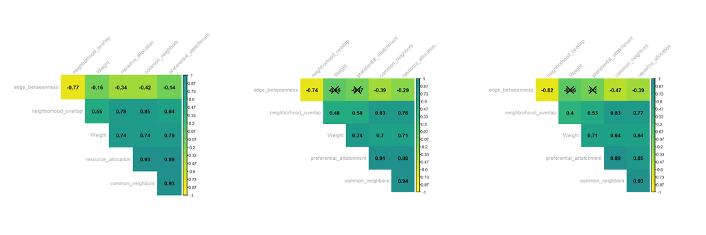

### Choosing the Number of Factors

```
## Parallel analysis suggests that the number of factors =  2  and the number of components =  NA
```

```
## Parallel analysis suggests that the number of factors =  2  and the number of components =  NA
```

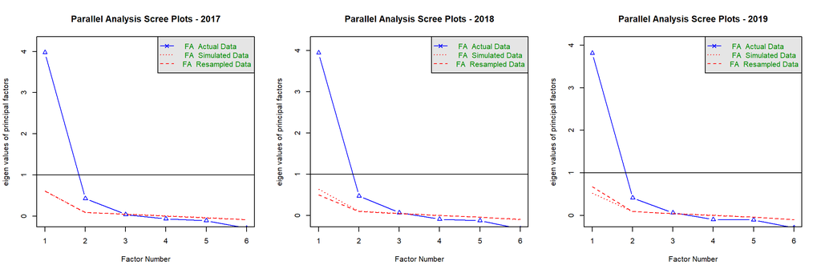

```
## Parallel analysis suggests that the number of factors =  2  and the number of components =  NA
```

### Factor Analysis

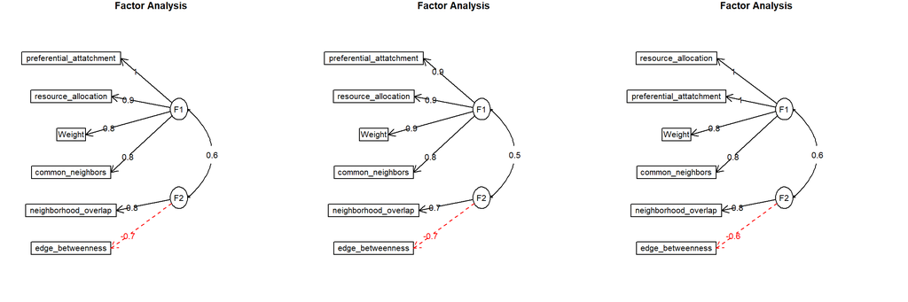

### Adequacy Test

```
## Factor Analysis using method =  ols
## Call: fa(r = data_2017, nfactors = 2, rotate = "oblimin", fm = "ols")
## Standardized loadings (pattern matrix) based upon correlation matrix
##                             1     2   h2    u2 com
## Weight                   0.84 -0.15 0.59 0.412 1.1
## common_neighbors         0.78  0.30 0.98 0.021 1.3
## neighborhood_overlap     0.22  0.83 0.95 0.050 1.1
## resource_allocation      0.88  0.11 0.91 0.088 1.0
## preferential_attatchment 1.00 -0.06 0.93 0.073 1.0
## edge_betweenness         0.19 -0.70 0.37 0.632 1.2
##
##                       [,1] [,2]
## SS loadings           3.30 1.42
## Proportion Var        0.55 0.24
## Cumulative Var        0.55 0.79
## Proportion Explained  0.70 0.30
## Cumulative Proportion 0.70 1.00
##
##  With factor correlations of
##      [,1] [,2]
## [1,] 1.00 0.59
## [2,] 0.59 1.00
##
## Mean item complexity =  1.1
## Test of the hypothesis that 2 factors are sufficient.
##
## The degrees of freedom for the null model are  15  and the objective function was  7.78 with Chi Square of  3952.04
## The degrees of freedom for the model are 4  and the objective function was  0.85
##
## The root mean square of the residuals (RMSR) is  0.02
## The df corrected root mean square of the residuals is  0.03
##
## The harmonic number of observations is  512 with the empirical chi square  4.92  with prob <  0.3
## The total number of observations was  512  with Likelihood Chi Square =  428.95  with prob <  1.5e-91
##
## Tucker Lewis Index of factoring reliability =  0.594
## RMSEA index =  0.456  and the 90 % confidence intervals are  0.42 0.493
## BIC =  404
## Fit based upon off diagonal values = 1
## Measures of factor score adequacy
##                                                   [,1] [,2]
## Correlation of (regression) scores with factors   0.99 0.98
## Multiple R square of scores with factors          0.98 0.97
## Minimum correlation of possible factor scores     0.95 0.94
```

```
## Factor Analysis using method =  ols
## Call: fa(r = data_2018, nfactors = 2, rotate = "oblimin", fm = "ols")
## Standardized loadings (pattern matrix) based upon correlation matrix
##                             1     2   h2    u2 com
## Weight                   0.89 -0.17 0.66 0.339 1.1
## common_neighbors         0.81  0.29 0.98 0.020 1.2
## neighborhood_overlap     0.31  0.74 0.88 0.123 1.3
## resource_allocation      0.92  0.07 0.92 0.082 1.0
## preferential_attatchment 0.95 -0.03 0.87 0.130 1.0
## edge_betweenness         0.16 -0.73 0.44 0.556 1.1
##
##                       [,1] [,2]
## SS loadings           3.43 1.32
## Proportion Var        0.57 0.22
## Cumulative Var        0.57 0.79
## Proportion Explained  0.72 0.28
## Cumulative Proportion 0.72 1.00
##
##  With factor correlations of
##      [,1] [,2]
## [1,] 1.00 0.51
## [2,] 0.51 1.00
##
## Mean item complexity =  1.1
## Test of the hypothesis that 2 factors are sufficient.
##
## The degrees of freedom for the null model are  15  and the objective function was  7.77 with Chi Square of  3962.07
## The degrees of freedom for the model are 4  and the objective function was  1.42
##
## The root mean square of the residuals (RMSR) is  0.02
## The df corrected root mean square of the residuals is  0.05
##
## The harmonic number of observations is  514 with the empirical chi square  9.21  with prob <  0.056
## The total number of observations was  514  with Likelihood Chi Square =  723.36  with prob <  3e-155
##
## Tucker Lewis Index of factoring reliability =  0.315
## RMSEA index =  0.592  and the 90 % confidence intervals are  0.556 0.629
## BIC =  698.39
## Fit based upon off diagonal values = 1
## Measures of factor score adequacy
##                                                   [,1] [,2]
## Correlation of (regression) scores with factors   0.99 0.97
## Multiple R square of scores with factors          0.99 0.94
## Minimum correlation of possible factor scores     0.98 0.87
```

```
## Factor Analysis using method =  ols
## Call: fa(r = data_2019, nfactors = 2, rotate = "oblimin", fm = "ols")
## Standardized loadings (pattern matrix) based upon correlation matrix
##                             1     2   h2    u2 com
## Weight                   0.83 -0.13 0.58 0.418 1.1
## common_neighbors         0.77  0.32 0.98 0.019 1.3
## neighborhood_overlap     0.15  0.83 0.86 0.138 1.1
## resource_allocation      0.96  0.05 0.97 0.030 1.0
## preferential_attatchment 0.95 -0.05 0.85 0.146 1.0
## edge_betweenness         0.20 -0.62 0.28 0.716 1.2
##
##                       [,1] [,2]
## SS loadings           3.26 1.28
## Proportion Var        0.54 0.21
## Cumulative Var        0.54 0.76
## Proportion Explained  0.72 0.28
## Cumulative Proportion 0.72 1.00
##
##  With factor correlations of
##      [,1] [,2]
## [1,] 1.00 0.58
## [2,] 0.58 1.00
##
## Mean item complexity =  1.1
## Test of the hypothesis that 2 factors are sufficient.
##
## The degrees of freedom for the null model are  15  and the objective function was  7.39 with Chi Square of  4234.66
## The degrees of freedom for the model are 4  and the objective function was  1.71
##
## The root mean square of the residuals (RMSR) is  0.03
## The df corrected root mean square of the residuals is  0.05
##
## The harmonic number of observations is  577 with the empirical chi square  11.74  with prob <  0.019
## The total number of observations was  577  with Likelihood Chi Square =  978.3  with prob <  1.8e-210
##
## Tucker Lewis Index of factoring reliability =  0.132
## RMSEA index =  0.65  and the 90 % confidence intervals are  0.616 0.685
## BIC =  952.86
## Fit based upon off diagonal values = 1
```

## Brazil

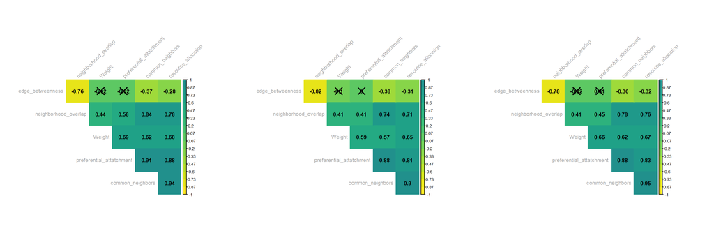

### Choosing the Number of Factors

```
## Parallel analysis suggests that the number of factors =  2  and the number of components =  NA
```

```
## Parallel analysis suggests that the number of factors =  3  and the number of components =  NA
```

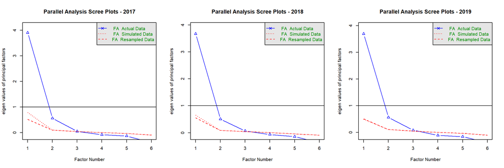

```
## Parallel analysis suggests that the number of factors =  3  and the number of components =  NA
```

### Factor Analysis

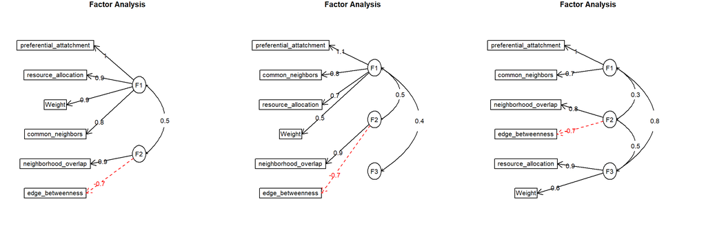

### Adequacy Test

```
## Factor Analysis using method =  ols
## Call: fa(r = data_2017, nfactors = 2, rotate = "oblimin", fm = "ols")
## Standardized loadings (pattern matrix) based upon correlation matrix
##                             1     2   h2    u2 com
## Weight                   0.85 -0.11 0.64 0.360 1.0
## common_neighbors         0.80  0.30 0.97 0.032 1.3
## neighborhood_overlap     0.17  0.89 0.98 0.015 1.1
## resource_allocation      0.89  0.13 0.92 0.079 1.0
## preferential_attatchment 1.01 -0.10 0.93 0.074 1.0
## edge_betweenness         0.18 -0.75 0.45 0.548 1.1
##
##                       [,1] [,2]
## SS loadings           3.32 1.57
## Proportion Var        0.55 0.26
## Cumulative Var        0.55 0.82
## Proportion Explained  0.68 0.32
## Cumulative Proportion 0.68 1.00
##
##  With factor correlations of
##      [,1] [,2]
## [1,] 1.00 0.51
## [2,] 0.51 1.00
##
## Mean item complexity =  1.1
## Test of the hypothesis that 2 factors are sufficient.
##
## The degrees of freedom for the null model are  15  and the objective function was  7.78 with Chi Square of  3496.47
## The degrees of freedom for the model are 4  and the objective function was  0.82
##
## The root mean square of the residuals (RMSR) is  0.02
## The df corrected root mean square of the residuals is  0.03
##
## The harmonic number of observations is  453 with the empirical chi square  4.42  with prob <  0.35
## The total number of observations was  453  with Likelihood Chi Square =  366.16  with prob <  5.7e-78
##
## Tucker Lewis Index of factoring reliability =  0.609
## RMSEA index =  0.447  and the 90 % confidence intervals are  0.409 0.487
## BIC =  341.69
## Fit based upon off diagonal values = 1
## Measures of factor score adequacy
##                                                   [,1] [,2]
## Correlation of (regression) scores with factors   0.99 1.00
## Multiple R square of scores with factors          0.98 0.99
## Minimum correlation of possible factor scores     0.95 0.99
```

```
## Factor Analysis using method =  ols
## Call: fa(r = data_2018, nfactors = 3, rotate = "oblimin", fm = "ols")
## Standardized loadings (pattern matrix) based upon correlation matrix
##                             1     2     3   h2     u2 com
## Weight                   0.54 -0.02  0.29 0.50 0.4983 1.5
## common_neighbors         0.85  0.28 -0.03 1.00 0.0041 1.2
## neighborhood_overlap     0.07  0.89  0.13 0.93 0.0650 1.1
## resource_allocation      0.68  0.20  0.29 0.91 0.0920 1.6
## preferential_attatchment 1.07 -0.13 -0.05 0.98 0.0237 1.0
## edge_betweenness         0.04 -0.73  0.22 0.49 0.5050 1.2
##
##                       [,1] [,2] [,3]
## SS loadings           2.86 1.59 0.36
## Proportion Var        0.48 0.26 0.06
## Cumulative Var        0.48 0.74 0.80
## Proportion Explained  0.59 0.33 0.08
## Cumulative Proportion 0.59 0.92 1.00
##
##  With factor correlations of
##      [,1] [,2] [,3]
## [1,] 1.00 0.48 0.42
## [2,] 0.48 1.00 0.22
## [3,] 0.42 0.22 1.00
##
## Mean item complexity =  1.3
## Test of the hypothesis that 3 factors are sufficient.
##
## The degrees of freedom for the null model are  15  and the objective function was  6.71 with Chi Square of  3490.18
## The degrees of freedom for the model are 0  and the objective function was  0.01
##
## The root mean square of the residuals (RMSR) is  0
## The df corrected root mean square of the residuals is  NA
##
## The harmonic number of observations is  524 with the empirical chi square  0.03  with prob <  NA
## The total number of observations was  524  with Likelihood Chi Square =  4.91  with prob <  NA
##
## Tucker Lewis Index of factoring reliability =  -Inf
## Fit based upon off diagonal values = 1
## Measures of factor score adequacy
##                                                   [,1] [,2] [,3]
## Correlation of (regression) scores with factors   1.00 0.98 0.80
## Multiple R square of scores with factors          0.99 0.95 0.64
## Minimum correlation of possible factor scores     0.98 0.91 0.28
```

```
## Factor Analysis using method =  ols
## Call: fa(r = data_2019, nfactors = 3, rotate = "oblimin", fm = "ols")
## Standardized loadings (pattern matrix) based upon correlation matrix
##                              1     2    3   h2     u2 com
## Weight                    0.27 -0.13 0.61 0.63 0.3744 1.5
## common_neighbors          0.67  0.35 0.16 0.99 0.0130 1.6
## neighborhood_overlap     -0.03  0.84 0.23 0.92 0.0846 1.2
## resource_allocation       0.05  0.10 0.89 0.98 0.0241 1.0
## preferential_attatchment  1.00 -0.07 0.03 1.00 0.0037 1.0
## edge_betweenness         -0.10 -0.73 0.22 0.46 0.5415 1.2
##
##                       [,1] [,2] [,3]
## SS loadings           1.85 1.50 1.60
## Proportion Var        0.31 0.25 0.27
## Cumulative Var        0.31 0.56 0.83
## Proportion Explained  0.37 0.30 0.32
## Cumulative Proportion 0.37 0.68 1.00
##
##  With factor correlations of
##      [,1] [,2] [,3]
## [1,] 1.00 0.35 0.81
## [2,] 0.35 1.00 0.48
## [3,] 0.81 0.48 1.00
##
## Mean item complexity =  1.3
## Test of the hypothesis that 3 factors are sufficient.
##
## The degrees of freedom for the null model are  15  and the objective function was  6.78 with Chi Square of  2631.74
## The degrees of freedom for the model are 0  and the objective function was  0.01
##
## The root mean square of the residuals (RMSR) is  0
## The df corrected root mean square of the residuals is  NA
##
## The harmonic number of observations is  392 with the empirical chi square  0.02  with prob <  NA
## The total number of observations was  392  with Likelihood Chi Square =  4.06  with prob <  NA
##
## Tucker Lewis Index of factoring reliability =  -Inf
## Fit based upon off diagonal values = 1
## Measures of factor score adequacy
##                                                   [,1] [,2] [,3]
## Correlation of (regression) scores with factors   1.00 0.98 0.99
## Multiple R square of scores with factors          1.00 0.95 0.97
## Minimum correlation of possible factor scores     0.99 0.91 0.95
```

## Canada

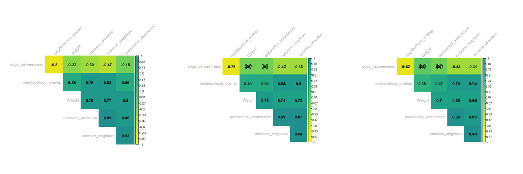

### Choosing the Number of Factors

```
## Parallel analysis suggests that the number of factors =  3  and the number of components =  NA
```

```
## Parallel analysis suggests that the number of factors =  3  and the number of components =  NA
```

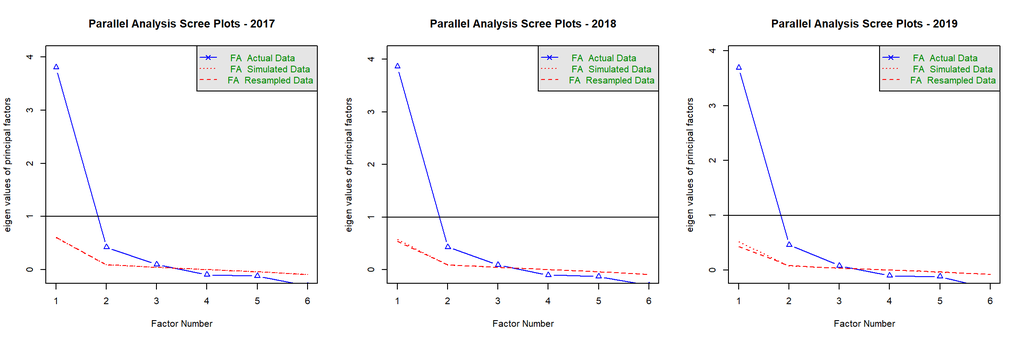

```
## Parallel analysis suggests that the number of factors =  3  and the number of components =  NA
```

### Factor Analysis

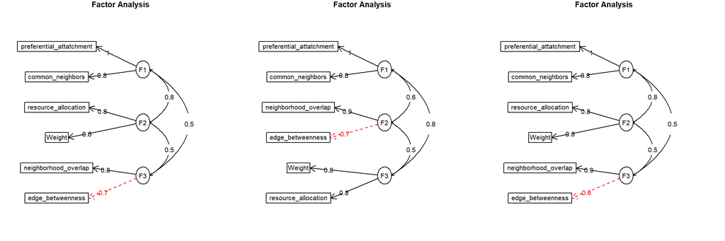

### Adequacy Test

```
## Factor Analysis using method =  ols
## Call: fa(r = data_2017, nfactors = 3, rotate = "oblimin", fm = "ols")
## Standardized loadings (pattern matrix) based upon correlation matrix
##                              1    2     3   h2      u2 com
## Weight                    0.09 0.62 -0.09 0.44  0.5638 1.1
## common_neighbors          0.77 0.08  0.27 1.00  0.0023 1.3
## neighborhood_overlap      0.02 0.33  0.76 0.95  0.0451 1.4
## resource_allocation       0.14 0.85  0.08 1.00 -0.0047 1.1
## preferential_attatchment  1.01 0.03 -0.10 0.98  0.0227 1.0
## edge_betweenness         -0.11 0.22 -0.72 0.47  0.5307 1.2
##
##                       [,1] [,2] [,3]
## SS loadings           1.95 1.53 1.36
## Proportion Var        0.32 0.26 0.23
## Cumulative Var        0.32 0.58 0.81
## Proportion Explained  0.40 0.32 0.28
## Cumulative Proportion 0.40 0.72 1.00
##
##  With factor correlations of
##      [,1] [,2] [,3]
## [1,] 1.00 0.83 0.48
## [2,] 0.83 1.00 0.47
## [3,] 0.48 0.47 1.00
##
## Mean item complexity =  1.2
## Test of the hypothesis that 3 factors are sufficient.
##
## The degrees of freedom for the null model are  15  and the objective function was  7.27 with Chi Square of  3900.18
## The degrees of freedom for the model are 0  and the objective function was  0.02
##
## The root mean square of the residuals (RMSR) is  0
## The df corrected root mean square of the residuals is  NA
##
## The harmonic number of observations is  540 with the empirical chi square  0.33  with prob <  NA
## The total number of observations was  540  with Likelihood Chi Square =  12.21  with prob <  NA
##
## Tucker Lewis Index of factoring reliability =  -Inf
## Fit based upon off diagonal values = 1
```

```
## Factor Analysis using method =  ols
## Call: fa(r = data_2018, nfactors = 3, rotate = "oblimin", fm = "ols")
## Standardized loadings (pattern matrix) based upon correlation matrix
##                              1     2    3   h2      u2 com
## Weight                   -0.02 -0.07 0.79 0.55  0.4530 1.0
## common_neighbors          0.76  0.28 0.06 1.00  0.0014 1.3
## neighborhood_overlap      0.02  0.87 0.18 0.97  0.0251 1.1
## resource_allocation       0.16  0.15 0.78 1.01 -0.0089 1.2
## preferential_attatchment  1.02 -0.10 0.03 0.98  0.0192 1.0
## edge_betweenness         -0.07 -0.68 0.23 0.39  0.6094 1.2
##
##                       [,1] [,2] [,3]
## SS loadings           1.91 1.49 1.50
## Proportion Var        0.32 0.25 0.25
## Cumulative Var        0.32 0.57 0.82
## Proportion Explained  0.39 0.30 0.31
## Cumulative Proportion 0.39 0.69 1.00
##
##  With factor correlations of
##      [,1] [,2] [,3]
## [1,] 1.00 0.58 0.83
## [2,] 0.58 1.00 0.49
## [3,] 0.83 0.49 1.00
##
## Mean item complexity =  1.1
## Test of the hypothesis that 3 factors are sufficient.
##
## The degrees of freedom for the null model are  15  and the objective function was  7.84 with Chi Square of  4343.58
## The degrees of freedom for the model are 0  and the objective function was  0.08
##
## The root mean square of the residuals (RMSR) is  0.01
## The df corrected root mean square of the residuals is  NA
##
## The harmonic number of observations is  558 with the empirical chi square  0.59  with prob <  NA
## The total number of observations was  558  with Likelihood Chi Square =  44.1  with prob <  NA
##
## Tucker Lewis Index of factoring reliability =  -Inf
## Fit based upon off diagonal values = 1
```

```
## Factor Analysis using method =  ols
## Call: fa(r = data_2019, nfactors = 3, rotate = "oblimin", fm = "ols")
## Standardized loadings (pattern matrix) based upon correlation matrix
##                              1    2     3   h2      u2 com
## Weight                   -0.02 0.76 -0.05 0.52  0.4782 1.0
## common_neighbors          0.76 0.08  0.29 1.00  0.0016 1.3
## neighborhood_overlap     -0.01 0.15  0.90 0.95  0.0542 1.1
## resource_allocation       0.15 0.82  0.11 1.01 -0.0086 1.1
## preferential_attatchment  1.00 0.04 -0.10 0.98  0.0204 1.0
## edge_betweenness         -0.12 0.26 -0.63 0.35  0.6541 1.4
##
##                       [,1] [,2] [,3]
## SS loadings           1.86 1.52 1.43
## Proportion Var        0.31 0.25 0.24
## Cumulative Var        0.31 0.56 0.80
## Proportion Explained  0.39 0.32 0.30
## Cumulative Proportion 0.39 0.70 1.00
##
##  With factor correlations of
##      [,1] [,2] [,3]
## [1,] 1.00 0.85 0.50
## [2,] 0.85 1.00 0.47
## [3,] 0.50 0.47 1.00
##
## Mean item complexity =  1.2
## Test of the hypothesis that 3 factors are sufficient.
##
## The degrees of freedom for the null model are  15  and the objective function was  7.28 with Chi Square of  4924
## The degrees of freedom for the model are 0  and the objective function was  0.03
##
## The root mean square of the residuals (RMSR) is  0.01
## The df corrected root mean square of the residuals is  NA
##
## The harmonic number of observations is  680 with the empirical chi square  0.71  with prob <  NA
## The total number of observations was  680  with Likelihood Chi Square =  20.46  with prob <  NA
##
## Tucker Lewis Index of factoring reliability =  -Inf
## Fit based upon off diagonal values = 1
```

## France

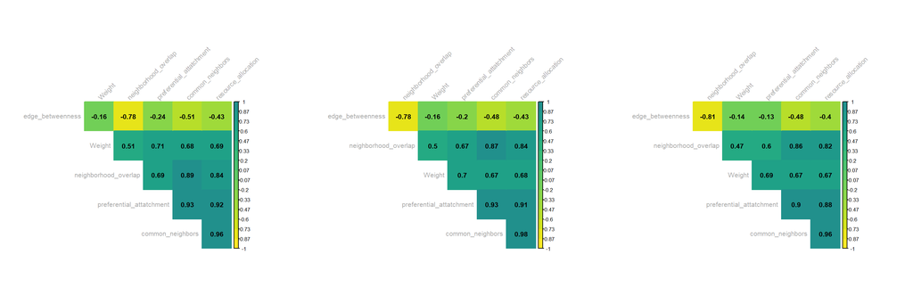

### Choosing the Number of Factors

```
## Parallel analysis suggests that the number of factors =  2  and the number of components =  NA
```

```
## Parallel analysis suggests that the number of factors =  3  and the number of components =  NA
```

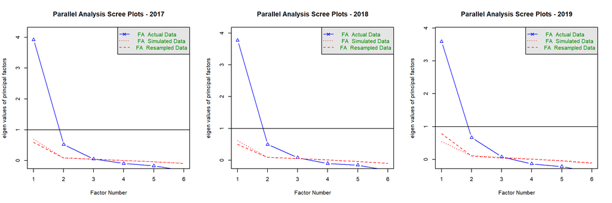

```
## Parallel analysis suggests that the number of factors =  2  and the number of components =  NA
```

### Factor Analysis

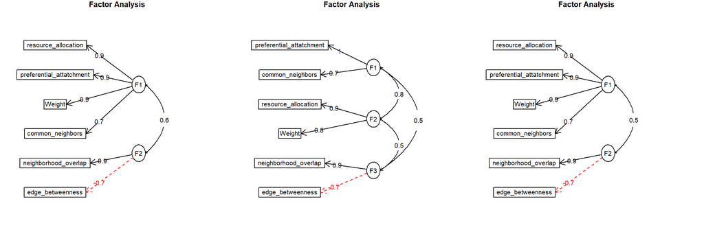

### Adequacy Test

```
## Factor Analysis using method =  ols
## Call: fa(r = data_2017, nfactors = 2, rotate = "oblimin", fm = "ols")
## Standardized loadings (pattern matrix) based upon correlation matrix
##                             1     2   h2    u2 com
## Weight                   0.86 -0.21 0.59 0.413 1.1
## common_neighbors         0.70  0.41 0.97 0.026 1.6
## neighborhood_overlap     0.18  0.87 0.97 0.030 1.1
## resource_allocation      0.95  0.06 0.96 0.040 1.0
## preferential_attatchment 0.90  0.04 0.85 0.147 1.0
## edge_betweenness         0.17 -0.75 0.45 0.553 1.1
##
##                       [,1] [,2]
## SS loadings           3.13 1.67
## Proportion Var        0.52 0.28
## Cumulative Var        0.52 0.80
## Proportion Explained  0.65 0.35
## Cumulative Proportion 0.65 1.00
##
##  With factor correlations of
##      [,1] [,2]
## [1,] 1.00 0.57
## [2,] 0.57 1.00
##
## Mean item complexity =  1.2
## Test of the hypothesis that 2 factors are sufficient.
##
## The degrees of freedom for the null model are  15  and the objective function was  8.22 with Chi Square of  3792.84
## The degrees of freedom for the model are 4  and the objective function was  2.04
##
## The root mean square of the residuals (RMSR) is  0.03
## The df corrected root mean square of the residuals is  0.05
##
## The harmonic number of observations is  465 with the empirical chi square  10  with prob <  0.04
## The total number of observations was  465  with Likelihood Chi Square =  939.23  with prob <  5.3e-202
##
## Tucker Lewis Index of factoring reliability =  0.069
## RMSEA index =  0.709  and the 90 % confidence intervals are  0.672 0.748
## BIC =  914.66
## Fit based upon off diagonal values = 1
```

```
## Factor Analysis using method =  ols
## Call: fa(r = data_2018, nfactors = 3, rotate = "oblimin", fm = "ols")
## Standardized loadings (pattern matrix) based upon correlation matrix
##                             1    2     3   h2      u2 com
## Weight                   0.00 0.79 -0.14 0.53  0.4737 1.1
## common_neighbors         0.70 0.09  0.34 1.00  0.0045 1.5
## neighborhood_overlap     0.05 0.16  0.85 0.96  0.0411 1.1
## resource_allocation      0.06 0.89  0.12 1.00 -0.0022 1.0
## preferential_attatchment 1.03 0.01 -0.08 0.99  0.0063 1.0
## edge_betweenness         0.01 0.16 -0.72 0.43  0.5668 1.1
##
##                       [,1] [,2] [,3]
## SS loadings           1.76 1.60 1.54
## Proportion Var        0.29 0.27 0.26
## Cumulative Var        0.29 0.56 0.82
## Proportion Explained  0.36 0.33 0.31
## Cumulative Proportion 0.36 0.69 1.00
##
##  With factor correlations of
##      [,1] [,2] [,3]
## [1,] 1.00 0.84 0.53
## [2,] 0.84 1.00 0.50
## [3,] 0.53 0.50 1.00
##
## Mean item complexity =  1.1
## Test of the hypothesis that 3 factors are sufficient.
##
## The degrees of freedom for the null model are  15  and the objective function was  7.43 with Chi Square of  3420.05
## The degrees of freedom for the model are 0  and the objective function was  0.13
##
## The root mean square of the residuals (RMSR) is  0
## The df corrected root mean square of the residuals is  NA
##
## The harmonic number of observations is  464 with the empirical chi square  0.35  with prob <  NA
## The total number of observations was  464  with Likelihood Chi Square =  57.81  with prob <  NA
##
## Tucker Lewis Index of factoring reliability =  -Inf
## Fit based upon off diagonal values = 1
```

```
## Factor Analysis using method =  ols
## Call: fa(r = data_2019, nfactors = 2, rotate = "oblimin", fm = "ols")
## Standardized loadings (pattern matrix) based upon correlation matrix
##                             1     2   h2    u2 com
## Weight                   0.87 -0.20 0.62 0.376 1.1
## common_neighbors         0.66  0.47 0.96 0.043 1.8
## neighborhood_overlap     0.10  0.91 0.93 0.069 1.0
## resource_allocation      0.93  0.06 0.93 0.074 1.0
## preferential_attatchment 0.87  0.04 0.80 0.200 1.0
## edge_betweenness         0.17 -0.72 0.43 0.566 1.1
##
##                       [,1] [,2]
## SS loadings           2.95 1.72
## Proportion Var        0.49 0.29
## Cumulative Var        0.49 0.78
## Proportion Explained  0.63 0.37
## Cumulative Proportion 0.63 1.00
##
##  With factor correlations of
##      [,1] [,2]
## [1,] 1.00 0.48
## [2,] 0.48 1.00
##
## Mean item complexity =  1.2
## Test of the hypothesis that 2 factors are sufficient.
##
## The degrees of freedom for the null model are  15  and the objective function was  7.06 with Chi Square of  3036.14
## The degrees of freedom for the model are 4  and the objective function was  1.77
##
## The root mean square of the residuals (RMSR) is  0.04
## The df corrected root mean square of the residuals is  0.07
##
## The harmonic number of observations is  434 with the empirical chi square  17.56  with prob <  0.0015
## The total number of observations was  434  with Likelihood Chi Square =  758.95  with prob <  6e-163
##
## Tucker Lewis Index of factoring reliability =  0.06
## RMSEA index =  0.659  and the 90 % confidence intervals are  0.621 0.7
## BIC =  734.66
## Fit based upon off diagonal values = 1
## Measures of factor score adequacy
##                                                   [,1] [,2]
## Correlation of (regression) scores with factors   1.00 0.98
## Multiple R square of scores with factors          0.99 0.96
## Minimum correlation of possible factor scores     0.99 0.92
```

## Germany

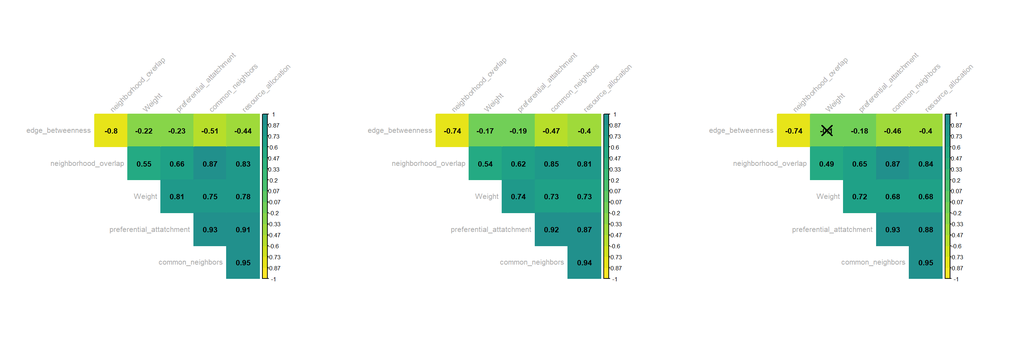

### Choosing the Number of Factors

```
## Parallel analysis suggests that the number of factors =  2  and the number of components =  NA
```

```
## Parallel analysis suggests that the number of factors =  3  and the number of components =  NA
```

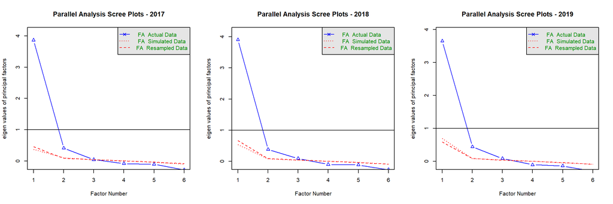

```
## Parallel analysis suggests that the number of factors =  3  and the number of components =  NA
```

### Factor Analysis

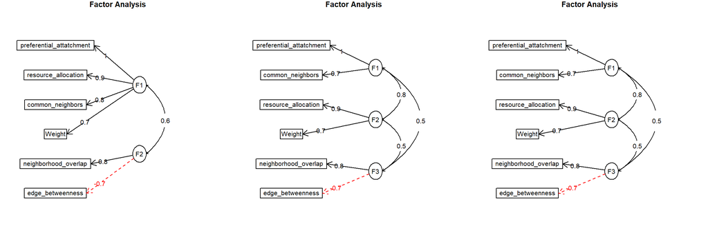

### Adequacy Test

```
## Factor Analysis using method =  ols
## Call: fa(r = data_2017, nfactors = 2, rotate = "oblimin", fm = "ols")
## Standardized loadings (pattern matrix) based upon correlation matrix
##                             1     2   h2     u2 com
## Weight                   0.74 -0.13 0.45 0.5494 1.1
## common_neighbors         0.80  0.28 0.99 0.0098 1.2
## neighborhood_overlap     0.25  0.79 0.93 0.0744 1.2
## resource_allocation      0.90  0.08 0.89 0.1078 1.0
## preferential_attatchment 0.99 -0.08 0.89 0.1076 1.0
## edge_betweenness         0.16 -0.74 0.43 0.5676 1.1
##
##                       [,1] [,2]
## SS loadings           3.18 1.40
## Proportion Var        0.53 0.23
## Cumulative Var        0.53 0.76
## Proportion Explained  0.69 0.31
## Cumulative Proportion 0.69 1.00
##
##  With factor correlations of
##      [,1] [,2]
## [1,]  1.0  0.6
## [2,]  0.6  1.0
##
## Mean item complexity =  1.1
## Test of the hypothesis that 2 factors are sufficient.
##
## The degrees of freedom for the null model are  15  and the objective function was  7.27 with Chi Square of  4009.33
## The degrees of freedom for the model are 4  and the objective function was  0.86
##
## The root mean square of the residuals (RMSR) is  0.02
## The df corrected root mean square of the residuals is  0.04
##
## The harmonic number of observations is  555 with the empirical chi square  6.14  with prob <  0.19
## The total number of observations was  555  with Likelihood Chi Square =  475.17  with prob <  1.6e-101
##
## Tucker Lewis Index of factoring reliability =  0.557
## RMSEA index =  0.461  and the 90 % confidence intervals are  0.427 0.497
## BIC =  449.89
## Fit based upon off diagonal values = 1
## Measures of factor score adequacy
##                                                   [,1] [,2]
## Correlation of (regression) scores with factors   0.99 0.97
## Multiple R square of scores with factors          0.99 0.95
## Minimum correlation of possible factor scores     0.98 0.89
```

```
## Factor Analysis using method =  ols
## Call: fa(r = data_2018, nfactors = 3, rotate = "oblimin", fm = "ols")
## Standardized loadings (pattern matrix) based upon correlation matrix
##                              1    2     3   h2      u2 com
## Weight                    0.06 0.74 -0.11 0.54  0.4583 1.1
## common_neighbors          0.70 0.13  0.29 1.00  0.0032 1.4
## neighborhood_overlap      0.04 0.26  0.79 0.94  0.0573 1.2
## resource_allocation       0.09 0.85  0.13 1.00 -0.0029 1.1
## preferential_attatchment  1.03 0.01 -0.07 0.99  0.0053 1.0
## edge_betweenness         -0.08 0.23 -0.68 0.38  0.6169 1.3
##
##                       [,1] [,2] [,3]
## SS loadings           1.86 1.63 1.37
## Proportion Var        0.31 0.27 0.23
## Cumulative Var        0.31 0.58 0.81
## Proportion Explained  0.38 0.34 0.28
## Cumulative Proportion 0.38 0.72 1.00
##
##  With factor correlations of
##      [,1] [,2] [,3]
## [1,] 1.00 0.84 0.54
## [2,] 0.84 1.00 0.53
## [3,] 0.54 0.53 1.00
##
## Mean item complexity =  1.2
## Test of the hypothesis that 3 factors are sufficient.
##
## The degrees of freedom for the null model are  15  and the objective function was  7.81 with Chi Square of  4577.09
## The degrees of freedom for the model are 0  and the objective function was  0.05
##
## The root mean square of the residuals (RMSR) is  0
## The df corrected root mean square of the residuals is  NA
##
## The harmonic number of observations is  590 with the empirical chi square  0.22  with prob <  NA
## The total number of observations was  590  with Likelihood Chi Square =  27.5  with prob <  NA
##
## Tucker Lewis Index of factoring reliability =  -Inf
## Fit based upon off diagonal values = 1
```

```
## Factor Analysis using method =  ols
## Call: fa(r = data_2019, nfactors = 3, rotate = "oblimin", fm = "ols")
## Standardized loadings (pattern matrix) based upon correlation matrix
##                              1    2     3   h2     u2 com
## Weight                   -0.06 0.74 -0.09 0.42 0.5772 1.0
## common_neighbors          0.70 0.09  0.34 1.00 0.0046 1.5
## neighborhood_overlap      0.05 0.18  0.83 0.92 0.0801 1.1
## resource_allocation       0.08 0.89  0.07 1.00 0.0034 1.0
## preferential_attatchment  1.02 0.02 -0.08 1.00 0.0047 1.0
## edge_betweenness          0.01 0.17 -0.71 0.41 0.5925 1.1
##
##                       [,1] [,2] [,3]
## SS loadings           1.74 1.54 1.45
## Proportion Var        0.29 0.26 0.24
## Cumulative Var        0.29 0.55 0.79
## Proportion Explained  0.37 0.32 0.31
## Cumulative Proportion 0.37 0.69 1.00
##
##  With factor correlations of
##      [,1] [,2] [,3]
## [1,] 1.00 0.83 0.53
## [2,] 0.83 1.00 0.52
## [3,] 0.53 0.52 1.00
##
## Mean item complexity =  1.1
## Test of the hypothesis that 3 factors are sufficient.
##
## The degrees of freedom for the null model are  15  and the objective function was  6.8 with Chi Square of  3529.51
## The degrees of freedom for the model are 0  and the objective function was  0
##
## The root mean square of the residuals (RMSR) is  0
## The df corrected root mean square of the residuals is  NA
##
## The harmonic number of observations is  523 with the empirical chi square  0.02  with prob <  NA
## The total number of observations was  523  with Likelihood Chi Square =  0.84  with prob <  NA
##
## Tucker Lewis Index of factoring reliability =  -Inf
## Fit based upon off diagonal values = 1
## Measures of factor score adequacy
##                                                   [,1] [,2] [,3]
## Correlation of (regression) scores with factors   1.00 1.00 0.99
## Multiple R square of scores with factors          1.00 1.00 0.97
## Minimum correlation of possible factor scores     0.99 0.99 0.94
```

## Japan

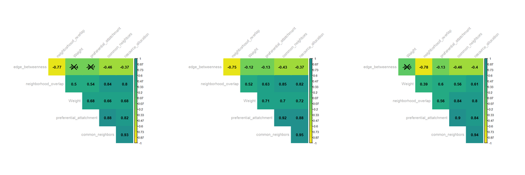

### Choosing the Number of Factors

```
## Parallel analysis suggests that the number of factors =  2  and the number of components =  NA
```

```
## Parallel analysis suggests that the number of factors =  2  and the number of components =  NA
```

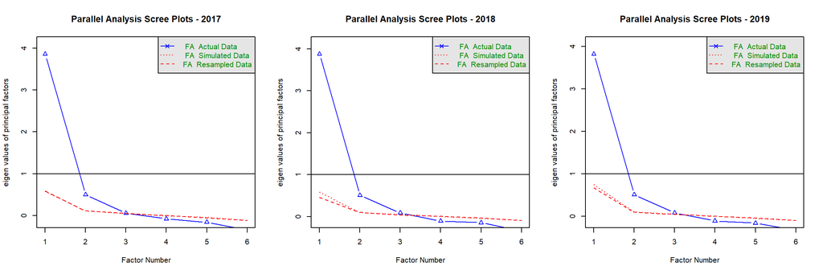

```
## Parallel analysis suggests that the number of factors =  3  and the number of components =  NA
```

### Factor Analysis

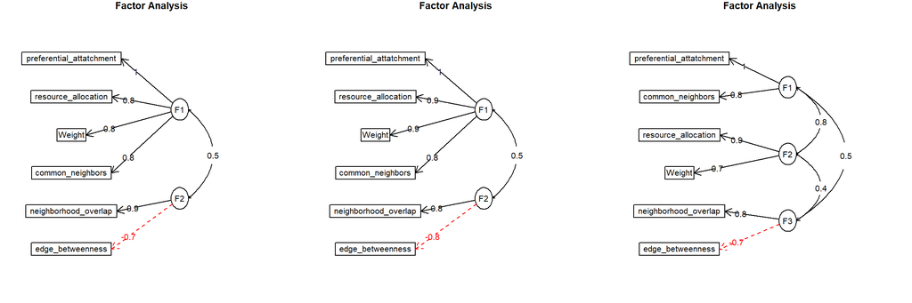

### Adequacy Test

```
## Factor Analysis using method =  ols
## Call: fa(r = data_2017, nfactors = 2, rotate = "oblimin", fm = "ols")
## Standardized loadings (pattern matrix) based upon correlation matrix
##                             1     2   h2    u2 com
## Weight                   0.80 -0.08 0.57 0.425 1.0
## common_neighbors         0.79  0.31 0.98 0.022 1.3
## neighborhood_overlap     0.18  0.87 0.96 0.039 1.1
## resource_allocation      0.80  0.21 0.87 0.129 1.1
## preferential_attatchment 1.03 -0.13 0.92 0.076 1.0
## edge_betweenness         0.17 -0.73 0.43 0.568 1.1
##
##                       [,1] [,2]
## SS loadings           3.14 1.60
## Proportion Var        0.52 0.27
## Cumulative Var        0.52 0.79
## Proportion Explained  0.66 0.34
## Cumulative Proportion 0.66 1.00
##
##  With factor correlations of
##      [,1] [,2]
## [1,] 1.00 0.54
## [2,] 0.54 1.00
##
## Mean item complexity =  1.1
## Test of the hypothesis that 2 factors are sufficient.
##
## The degrees of freedom for the null model are  15  and the objective function was  7.12 with Chi Square of  2465.63
## The degrees of freedom for the model are 4  and the objective function was  0.57
##
## The root mean square of the residuals (RMSR) is  0.02
## The df corrected root mean square of the residuals is  0.04
##
## The harmonic number of observations is  350 with the empirical chi square  4.26  with prob <  0.37
## The total number of observations was  350  with Likelihood Chi Square =  197.78  with prob <  1.1e-41
##
## Tucker Lewis Index of factoring reliability =  0.702
## RMSEA index =  0.372  and the 90 % confidence intervals are  0.329 0.418
## BIC =  174.35
## Fit based upon off diagonal values = 1
## Measures of factor score adequacy
##                                                   [,1] [,2]
## Correlation of (regression) scores with factors   0.99 0.99
## Multiple R square of scores with factors          0.97 0.98
## Minimum correlation of possible factor scores     0.94 0.96
```

```
## Factor Analysis using method =  ols
## Call: fa(r = data_2018, nfactors = 2, rotate = "oblimin", fm = "ols")
## Standardized loadings (pattern matrix) based upon correlation matrix
##                             1     2   h2    u2 com
## Weight                   0.86 -0.17 0.62 0.377 1.1
## common_neighbors         0.79  0.30 0.97 0.032 1.3
## neighborhood_overlap     0.27  0.80 0.93 0.066 1.2
## resource_allocation      0.87  0.12 0.88 0.118 1.0
## preferential_attatchment 0.96 -0.06 0.87 0.134 1.0
## edge_betweenness         0.17 -0.76 0.48 0.521 1.1
##
##                       [,1] [,2]
## SS loadings           3.28 1.47
## Proportion Var        0.55 0.25
## Cumulative Var        0.55 0.79
## Proportion Explained  0.69 0.31
## Cumulative Proportion 0.69 1.00
##
##  With factor correlations of
##      [,1] [,2]
## [1,] 1.00 0.52
## [2,] 0.52 1.00
##
## Mean item complexity =  1.1
## Test of the hypothesis that 2 factors are sufficient.
##
## The degrees of freedom for the null model are  15  and the objective function was  7.4 with Chi Square of  3605.06
## The degrees of freedom for the model are 4  and the objective function was  1.32
##
## The root mean square of the residuals (RMSR) is  0.03
## The df corrected root mean square of the residuals is  0.06
##
## The harmonic number of observations is  491 with the empirical chi square  12.38  with prob <  0.015
## The total number of observations was  491  with Likelihood Chi Square =  642.15  with prob <  1.2e-137
##
## Tucker Lewis Index of factoring reliability =  0.332
## RMSEA index =  0.57  and the 90 % confidence intervals are  0.534 0.608
## BIC =  617.37
## Fit based upon off diagonal values = 1
## Measures of factor score adequacy
##                                                   [,1] [,2]
## Correlation of (regression) scores with factors   0.99 0.98
## Multiple R square of scores with factors          0.97 0.96
## Minimum correlation of possible factor scores     0.95 0.92
```

```
## Factor Analysis using method =  ols
## Call: fa(r = data_2019, nfactors = 3, rotate = "oblimin", fm = "ols")
## Standardized loadings (pattern matrix) based upon correlation matrix
##                              1    2     3   h2      u2 com
## Weight                    0.16 0.71 -0.16 0.63  0.3746 1.2
## common_neighbors          0.76 0.05  0.32 0.99  0.0092 1.4
## neighborhood_overlap      0.04 0.22  0.84 0.96  0.0390 1.1
## resource_allocation       0.04 0.90  0.14 1.00 -0.0028 1.0
## preferential_attatchment  0.99 0.05 -0.09 1.00  0.0030 1.0
## edge_betweenness         -0.11 0.22 -0.66 0.39  0.6077 1.3
##
##                       [,1] [,2] [,3]
## SS loadings           1.90 1.64 1.43
## Proportion Var        0.32 0.27 0.24
## Cumulative Var        0.32 0.59 0.83
## Proportion Explained  0.38 0.33 0.29
## Cumulative Proportion 0.38 0.71 1.00
##
##  With factor correlations of
##      [,1] [,2] [,3]
## [1,] 1.00 0.84 0.46
## [2,] 0.84 1.00 0.45
## [3,] 0.46 0.45 1.00
##
## Mean item complexity =  1.2
## Test of the hypothesis that 3 factors are sufficient.
##
## The degrees of freedom for the null model are  15  and the objective function was  7.46 with Chi Square of  3088.4
## The degrees of freedom for the model are 0  and the objective function was  0.26
##
## The root mean square of the residuals (RMSR) is  0.01
## The df corrected root mean square of the residuals is  NA
##
## The harmonic number of observations is  418 with the empirical chi square  0.56  with prob <  NA
## The total number of observations was  418  with Likelihood Chi Square =  108.52  with prob <  NA
##
## Tucker Lewis Index of factoring reliability =  -Inf
## Fit based upon off diagonal values = 1
```

## UK

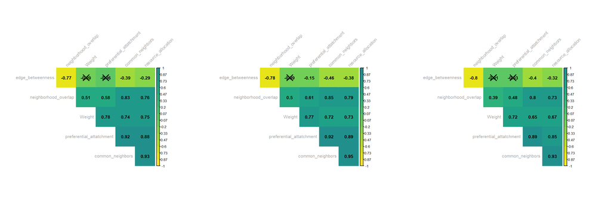

### Choosing the Number of Factors

```
## Parallel analysis suggests that the number of factors =  2  and the number of components =  NA
```

```
## Parallel analysis suggests that the number of factors =  3  and the number of components =  NA
```

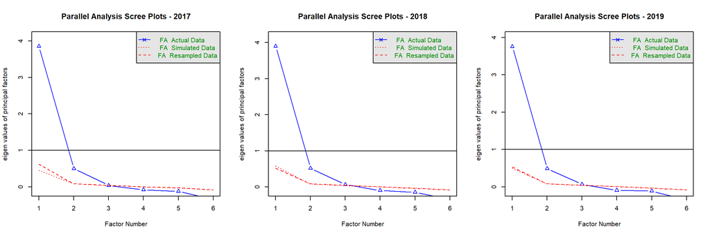

```
## Parallel analysis suggests that the number of factors =  3  and the number of components =  NA
```

### Factor Analysis

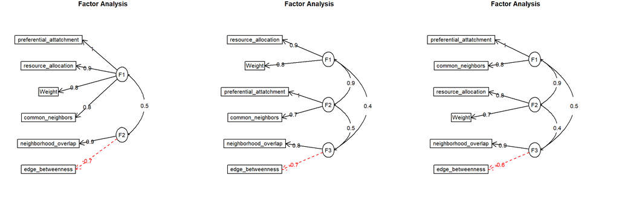

### Adequacy Test

```
## Factor Analysis using method =  ols
## Call: fa(r = data_2017, nfactors = 2, rotate = "oblimin", fm = "ols")
## Standardized loadings (pattern matrix) based upon correlation matrix
##                             1     2   h2    u2 com
## Weight                   0.85 -0.13 0.62 0.383 1.0
## common_neighbors         0.77  0.32 0.97 0.033 1.3
## neighborhood_overlap     0.15  0.89 0.95 0.048 1.1
## resource_allocation      0.89  0.11 0.90 0.099 1.0
## preferential_attatchment 1.00 -0.07 0.93 0.074 1.0
## edge_betweenness         0.18 -0.70 0.38 0.622 1.1
##
##                       [,1] [,2]
## SS loadings           3.25 1.50
## Proportion Var        0.54 0.25
## Cumulative Var        0.54 0.79
## Proportion Explained  0.68 0.32
## Cumulative Proportion 0.68 1.00
##
##  With factor correlations of
##      [,1] [,2]
## [1,] 1.00 0.54
## [2,] 0.54 1.00
##
## Mean item complexity =  1.1
## Test of the hypothesis that 2 factors are sufficient.
##
## The degrees of freedom for the null model are  15  and the objective function was  7.25 with Chi Square of  4397.54
## The degrees of freedom for the model are 4  and the objective function was  0.73
##
## The root mean square of the residuals (RMSR) is  0.02
## The df corrected root mean square of the residuals is  0.04
##
## The harmonic number of observations is  610 with the empirical chi square  6.13  with prob <  0.19
## The total number of observations was  610  with Likelihood Chi Square =  443.54  with prob <  1.1e-94
##
## Tucker Lewis Index of factoring reliability =  0.623
## RMSEA index =  0.424  and the 90 % confidence intervals are  0.392 0.459
## BIC =  417.88
## Fit based upon off diagonal values = 1
## Measures of factor score adequacy
##                                                   [,1] [,2]
## Correlation of (regression) scores with factors   0.99 0.98
## Multiple R square of scores with factors          0.97 0.96
## Minimum correlation of possible factor scores     0.94 0.93
```

```
## Factor Analysis using method =  ols
## Call: fa(r = data_2018, nfactors = 3, rotate = "oblimin", fm = "ols")
## Standardized loadings (pattern matrix) based upon correlation matrix
##                             1     2     3   h2      u2 com
## Weight                   0.80  0.09 -0.12 0.69 0.31053 1.1
## common_neighbors         0.09  0.72  0.32 1.00 0.00418 1.4
## neighborhood_overlap     0.21  0.03  0.84 0.94 0.05927 1.1
## resource_allocation      0.91  0.03  0.11 1.00 0.00032 1.0
## preferential_attatchment 0.03  1.01 -0.08 1.00 0.00448 1.0
## edge_betweenness         0.22 -0.08 -0.70 0.43 0.56954 1.2
##
##                       [,1] [,2] [,3]
## SS loadings           1.76 1.83 1.47
## Proportion Var        0.29 0.30 0.24
## Cumulative Var        0.29 0.60 0.84
## Proportion Explained  0.35 0.36 0.29
## Cumulative Proportion 0.35 0.71 1.00
##
##  With factor correlations of
##      [,1] [,2] [,3]
## [1,] 1.00 0.85 0.45
## [2,] 0.85 1.00 0.50
## [3,] 0.45 0.50 1.00
##
## Mean item complexity =  1.1
## Test of the hypothesis that 3 factors are sufficient.
##
## The degrees of freedom for the null model are  15  and the objective function was  7.83 with Chi Square of  4708.92
## The degrees of freedom for the model are 0  and the objective function was  0.04
##
## The root mean square of the residuals (RMSR) is  0
## The df corrected root mean square of the residuals is  NA
##
## The harmonic number of observations is  605 with the empirical chi square  0.14  with prob <  NA
## The total number of observations was  605  with Likelihood Chi Square =  24.88  with prob <  NA
##
## Tucker Lewis Index of factoring reliability =  -Inf
## Fit based upon off diagonal values = 1
```

```
## Factor Analysis using method =  ols
## Call: fa(r = data_2019, nfactors = 3, rotate = "oblimin", fm = "ols")
## Standardized loadings (pattern matrix) based upon correlation matrix
##                              1    2     3   h2      u2 com
## Weight                    0.13 0.67 -0.06 0.58  0.4242 1.1
## common_neighbors          0.76 0.08  0.28 1.00  0.0028 1.3
## neighborhood_overlap     -0.01 0.21  0.86 0.93  0.0706 1.1
## resource_allocation       0.12 0.85  0.11 1.00 -0.0031 1.1
## preferential_attatchment  0.98 0.06 -0.11 0.98  0.0187 1.0
## edge_betweenness         -0.16 0.29 -0.65 0.38  0.6187 1.5
##
##                       [,1] [,2] [,3]
## SS loadings           1.92 1.56 1.39
## Proportion Var        0.32 0.26 0.23
## Cumulative Var        0.32 0.58 0.81
## Proportion Explained  0.40 0.32 0.29
## Cumulative Proportion 0.40 0.71 1.00
##
##  With factor correlations of
##      [,1] [,2] [,3]
## [1,] 1.00 0.85 0.46
## [2,] 0.85 1.00 0.43
## [3,] 0.46 0.43 1.00
##
## Mean item complexity =  1.2
## Test of the hypothesis that 3 factors are sufficient.
##
## The degrees of freedom for the null model are  15  and the objective function was  7.21 with Chi Square of  4492.7
## The degrees of freedom for the model are 0  and the objective function was  0.03
##
## The root mean square of the residuals (RMSR) is  0
## The df corrected root mean square of the residuals is  NA
##
## The harmonic number of observations is  627 with the empirical chi square  0.28  with prob <  NA
## The total number of observations was  627  with Likelihood Chi Square =  16.24  with prob <  NA
##
## Tucker Lewis Index of factoring reliability =  -Inf
## Fit based upon off diagonal values = 1
```

## US

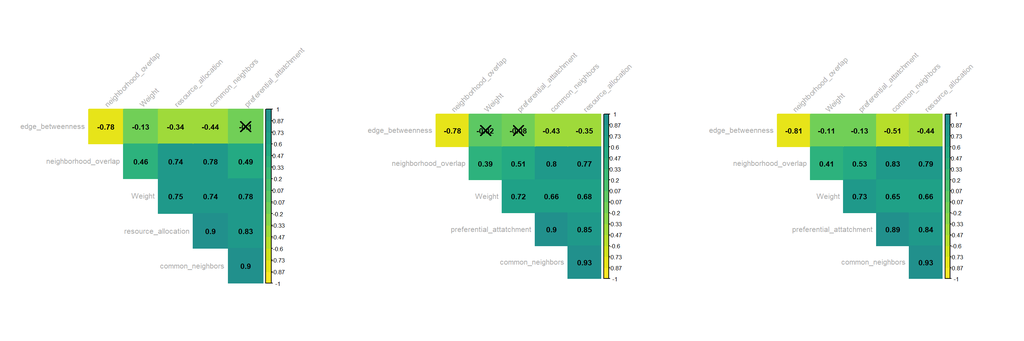

### Choosing the Number of Factors

```
## Parallel analysis suggests that the number of factors =  3  and the number of components =  NA
```

```
## Parallel analysis suggests that the number of factors =  3  and the number of components =  NA
```

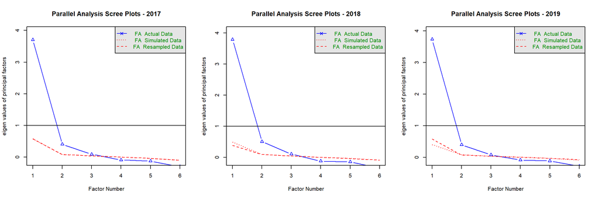

```
## Parallel analysis suggests that the number of factors =  3  and the number of components =  NA
```

### Factor Analysis

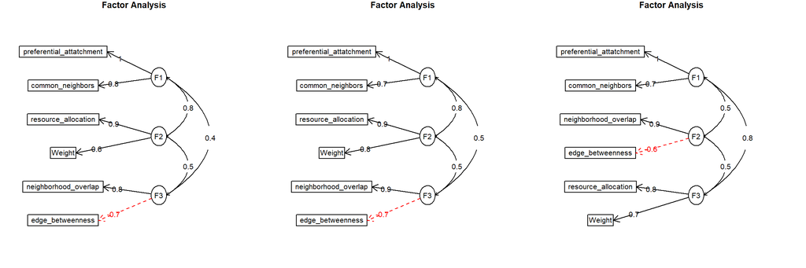

### Adequacy Test

```
## Factor Analysis using method =  ols
## Call: fa(r = data_2017, nfactors = 3, rotate = "oblimin", fm = "ols")
## Standardized loadings (pattern matrix) based upon correlation matrix
##                              1    2     3   h2     u2 com
## Weight                    0.14 0.60 -0.08 0.46 0.5380 1.1
## common_neighbors          0.76 0.10  0.28 1.00 0.0017 1.3
## neighborhood_overlap      0.01 0.31  0.76 0.90 0.1040 1.3
## resource_allocation       0.11 0.87  0.07 1.00 0.0012 1.0
## preferential_attatchment  1.00 0.03 -0.09 0.98 0.0180 1.0
## edge_betweenness         -0.13 0.25 -0.67 0.39 0.6072 1.4
##
##                       [,1] [,2] [,3]
## SS loadings           1.93 1.54 1.26
## Proportion Var        0.32 0.26 0.21
## Cumulative Var        0.32 0.58 0.79
## Proportion Explained  0.41 0.33 0.27
## Cumulative Proportion 0.41 0.73 1.00
##
##  With factor correlations of
##      [,1] [,2] [,3]
## [1,] 1.00 0.83 0.45
## [2,] 0.83 1.00 0.48
## [3,] 0.45 0.48 1.00
##
## Mean item complexity =  1.2
## Test of the hypothesis that 3 factors are sufficient.
##
## The degrees of freedom for the null model are  15  and the objective function was  6.75 with Chi Square of  3635.07
## The degrees of freedom for the model are 0  and the objective function was  0.02
##
## The root mean square of the residuals (RMSR) is  0
## The df corrected root mean square of the residuals is  NA
##
## The harmonic number of observations is  542 with the empirical chi square  0.12  with prob <  NA
## The total number of observations was  542  with Likelihood Chi Square =  8.79  with prob <  NA
##
## Tucker Lewis Index of factoring reliability =  -Inf
## Fit based upon off diagonal values = 1
## Measures of factor score adequacy
##                                                   [,1] [,2] [,3]
## Correlation of (regression) scores with factors   1.00    1 0.97
## Multiple R square of scores with factors          0.99    1 0.95
## Minimum correlation of possible factor scores     0.98    1 0.90
```

```
## Factor Analysis using method =  ols
## Call: fa(r = data_2018, nfactors = 3, rotate = "oblimin", fm = "ols")
## Standardized loadings (pattern matrix) based upon correlation matrix
##                              1    2     3   h2      u2 com
## Weight                   -0.02 0.81 -0.10 0.57  0.4278 1.0
## common_neighbors          0.74 0.08  0.31 1.00  0.0038 1.4
## neighborhood_overlap      0.03 0.19  0.86 0.96  0.0401 1.1
## resource_allocation       0.09 0.87  0.11 1.01 -0.0074 1.1
## preferential_attatchment  1.02 0.02 -0.09 0.99  0.0117 1.0
## edge_betweenness         -0.03 0.18 -0.74 0.46  0.5418 1.1
##
##                       [,1] [,2] [,3]
## SS loadings           1.82 1.64 1.53
## Proportion Var        0.30 0.27 0.25
## Cumulative Var        0.30 0.58 0.83
## Proportion Explained  0.36 0.33 0.31
## Cumulative Proportion 0.36 0.69 1.00
##
##  With factor correlations of
##      [,1] [,2] [,3]
## [1,] 1.00 0.83 0.50
## [2,] 0.83 1.00 0.48
## [3,] 0.50 0.48 1.00
##
## Mean item complexity =  1.1
## Test of the hypothesis that 3 factors are sufficient.
##
## The degrees of freedom for the null model are  15  and the objective function was  7.47 with Chi Square of  3870.36
## The degrees of freedom for the model are 0  and the objective function was  0.09
##
## The root mean square of the residuals (RMSR) is  0.01
## The df corrected root mean square of the residuals is  NA
##
## The harmonic number of observations is  522 with the empirical chi square  0.66  with prob <  NA
## The total number of observations was  522  with Likelihood Chi Square =  47.86  with prob <  NA
##
## Tucker Lewis Index of factoring reliability =  -Inf
## Fit based upon off diagonal values = 1
```

```
## Factor Analysis using method =  ols
## Call: fa(r = data_2019, nfactors = 3, rotate = "oblimin", fm = "ols")
## Standardized loadings (pattern matrix) based upon correlation matrix
##                              1     2    3   h2      u2 com
## Weight                   -0.01 -0.06 0.69 0.43  0.5721 1.0
## common_neighbors          0.72  0.31 0.09 1.00  0.0024 1.4
## neighborhood_overlap     -0.01  0.88 0.17 0.96  0.0430 1.1
## resource_allocation       0.16  0.12 0.80 1.01 -0.0070 1.1
## preferential_attatchment  1.00 -0.09 0.05 0.98  0.0186 1.0
## edge_betweenness         -0.13 -0.63 0.25 0.34  0.6611 1.4
##
##                       [,1] [,2] [,3]
## SS loadings           1.85 1.45 1.41
## Proportion Var        0.31 0.24 0.24
## Cumulative Var        0.31 0.55 0.78
## Proportion Explained  0.39 0.31 0.30
## Cumulative Proportion 0.39 0.70 1.00
##
##  With factor correlations of
##      [,1] [,2] [,3]
## [1,] 1.00 0.53 0.85
## [2,] 0.53 1.00 0.53
## [3,] 0.85 0.53 1.00
##
## Mean item complexity =  1.2
## Test of the hypothesis that 3 factors are sufficient.
##
## The degrees of freedom for the null model are  15  and the objective function was  7.3 with Chi Square of  4866.33
## The degrees of freedom for the model are 0  and the objective function was  0.03
##
## The root mean square of the residuals (RMSR) is  0.01
## The df corrected root mean square of the residuals is  NA
##
## The harmonic number of observations is  670 with the empirical chi square  0.62  with prob <  NA
## The total number of observations was  670  with Likelihood Chi Square =  21.8  with prob <  NA
##
## Tucker Lewis Index of factoring reliability =  -Inf
## Fit based upon off diagonal values = 1
```

# Naming the Factors

| Attractiveness | Influence | Affinity |
| --- | --- | --- |
| preferential_attatchment | neighborhood_overlap | resource_allocation |
| common_neighbors | edge_betweenness | weight |

- **Attractiveness** = corresponds to the predisposition of two nodes to connect in the future
- **Influence** = corresponds to the importance level of an edge in relation to access to different regions in the graph
- **Affinity** = corresponds to the frequency of collaboration between two nodes

A work by [Mariana O. S. Silva](https://github.com/marianaossilva/)

*marianaossilva@gmail.com*